Question 1

```python
import math
class optimise():
    def __init__(self,function):
        self.function=function
    def bisect_midpoint(self,a,b):
        result=(a+b)/2
        return(result)
    def bisect_checker(self,a,b,c,epsilon,delta):
        if abs(self.function(c))<delta:
            return False
        if abs(b-a)<=epsilon*(1+abs(a)+abs(b)):
            return False
        else:
            return True
    def bisection(self,a_init,b_init,delta,epsilon):
        #check condition
        assert self.function(a_init)*self.function(b_init)<0
        assert a_init<b_init;
        #check if increasing or decreasing
        if self.function(a_init)<0:
            self.bisec_status=True
        if self.function(a_init)>0:
            self.bisec_status=False
        else:
            print("a is the root")
        a=a_init
        b=b_init
        #step 3.
        c=self.bisect_midpoint(a,b)
        count=0
        while self.bisect_checker(a,b,c,epsilon,delta):
            count+=1
#            print("in loop")
            c=self.bisect_midpoint(a,b)
#            print(["c","f(c)",c,self.function(c)])
            if self.bisec_status==True:
        #action if increasing
                if self.function(c)<0:
                    a=c
                if self.function(c)>0:
                    b=c
            else:
        #action if decreasing
                if self.function(c)<0:
                    b=c
                if self.function(c)>0:
                    a=c
        #step 4
        print(["number of iterations",count])
        return(c)
    def stopping_criterion(self,x_n,xn1,epsilon):
        if abs(x_n-xn1)<=epsilon*(1+abs(xn1)):
            return False
        else:
            return True

    def newton(self,epsilon,delta,x_init,derivative_function):
        xn=x_init
        xn1=xn-self.function(xn)/derivative_function(xn)
        count=1
        while self.stopping_criterion(xn,xn1,epsilon):
            count+=1
#            print(["xn+1","xn",xn1,xn])
            xn=xn1
            xn1=xn-self.function(xn)/derivative_function(xn)
        print(["number of iterations",count])
        if abs(self.function(xn1))<delta:
            print("SUCCESS")
            print(["f(xn+1)","xn+1",self.function(xn1),xn1])
            return(xn1)
        else:
            print("Failure")
            return(False)
    def secant(self,epsilon,delta,x_init1,x_init2):
        xnp=x_init2
        xn=x_init1
        xn1=xn-self.function(xn)*(xn-xnp)/(self.function(xn)-self.function(xnp))
        count=1
        while self.stopping_criterion(xn,xn1,epsilon):
            count+=1
#            print(["xn+1","xn","xnp",xn1,xn,xnp])
            xnp=xn
            xn=xn1
            xn1=xn-self.function(xn)*(xn-xnp)/(self.function(xn)-self.function(xnp))
        print(["number of iterations",count])
        if abs(self.function(xn1))<delta:
            print("SUCCESS")
            print(["f(xn+1)","xn+1",self.function(xn1),xn1])
            return(xn1)
        else:
            print("Failure")
            return(False)
    def fixed_point(self,epsilon,delta,x_init):
        xn=x_init
        xn1=self.function(xn)
        count=1
        while self.stopping_criterion(xn,xn1,epsilon):
            count+=1
#            print(["xn+1","xn",xn1,xn])
            xn=xn1
            xn1=self.function(xn)
        print(["number of iterations",count])
        if abs(self.function(xn1))<delta:
            print("SUCCESS")
            print(["f(xn+1)","xn+1",self.function(xn1),xn1])
            return(xn1)
        else:
            print("Failure")
            return(False)
```

Bisection method

```python
def quest1_1(x):
    result=math.sin(2*math.pi*x)-2*x
#    result=pow((x-1),2)-1
    return(result)
def quest1_2(x):
    result=math.sin(2*math.pi*x)-x
#    result=pow((x-1),2)-1
    return(result)
def quest1_3(x):
    result=math.sin(2*math.pi*x)-0.5*x
#    result=pow((x-1),2)-1
    return(result)
optimiser=optimise(quest1_1)
print(optimiser.bisection(-100,5,0.1,0.1))
optimiser2=optimise(quest1_2)
print(optimiser2.bisection(-100,5,0.1,0.1))
optimiser3=optimise(quest1_3)
print(optimiser3.bisection(-100,5,0.1,0.1))
```

```
['number of iterations', 10]
0.3857421875
['number of iterations', 10]
0.3857421875
['number of iterations', 10]
0.3857421875
```

Newton method. (does not converge for the 3rd function)

```python
def derivative_function(x):
    return(2*math.pi*math.cos(2*math.pi*x)-2)
def derivative_function2(x):
    return(2*math.pi*math.cos(2*math.pi*x)-1)
def derivative_function3(x):
    return(2*math.pi*math.cos(2*math.pi*x)-0.5)
print(optimiser.newton(0.001,0.001,2,derivative_function))
print(optimiser.newton(0.001,0.001,-2,derivative_function))
print(optimiser2.newton(0.001,0.001,2,derivative_function2))
print(optimiser2.newton(0.001,0.001,-2,derivative_function2))
print(optimiser3.newton(0.001,0.001,2,derivative_function3))
print(optimiser3.newton(0.001,0.001,-2,derivative_function3))
#does not converge for the 3 question
```

```
['number of iterations', 1641]
SUCCESS
['f(xn+1)', 'xn+1', 3.5323981061276307e-12, 8.247128837051559e-13]
8.247128837051559e-13
['number of iterations', 1641]
SUCCESS
['f(xn+1)', 'xn+1', -3.5323981061276307e-12, -8.247128837051559e-13]
-8.247128837051559e-13
['number of iterations', 26]
SUCCESS
['f(xn+1)', 'xn+1', 6.090238891938359e-20, 1.1527589016538994e-20]
1.1527589016538994e-20
['number of iterations', 26]
SUCCESS
['f(xn+1)', 'xn+1', -6.090238891938359e-20, -1.1527589016538994e-20]
-1.1527589016538994e-20
```

[output not shown]

Secant method

```python
optimiser.secant(0.001,0.001,0.123,0.234)
optimiser2.secant(0.001,0.001,0.123,0.234)
optimiser3.secant(0.001,0.001,0.123,0.234)
```

```
['number of iterations', 9]
SUCCESS
['f(xn+1)', 'xn+1', 1.0775458872513966e-05, 0.368240500120094]
['number of iterations', 5]
SUCCESS
['f(xn+1)', 'xn+1', 2.789773492685561e-07, 5.2804763234302193e-08]
['number of iterations', 5]
SUCCESS
['f(xn+1)', 'xn+1', 9.398223495491073e-11, 1.6250946487610498e-11]
```

```
1.6250946487610498e-11
```

Fixed point iteration (does not converge at all)

```python
#optimiser.fixed_point(0.001,0.001,0.345)
#optimiser2.fixed_point(0.001,0.001,0.345)
optimiser3.fixed_point(0.001,0.001,0.345)
#explodes, so no answer. This is because the function is not a contraction
```

[output not shown]

Secant is the fastest. Fixed point iteration explodes, as not contraction. Newton takes too many iteration. Bisection is not bad.

Question2

Polytope method

```python
def quest2(array):
    x=array[0]
    y=array[1]
    result=100*pow((y-pow(x,2)),2)+pow((1-x),2)
    return(result)
import scipy.optimize
import numpy as np
#polytope
x0=np.array((1.5,0.8))
print(scipy.optimize.minimize(quest2,x0,method='Nelder-Mead'))
x0=np.array((7,8))
print(scipy.optimize.minimize(quest2,x0,method='Nelder-Mead'))
x0=np.array((200,200))
print(scipy.optimize.minimize(quest2,x0,method='Nelder-Mead'))
```

```
 final_simplex: (array([[ 1.0000018 ,  1.00000592],
       [ 0.99995573,  0.99991266],
       [ 0.99998885,  0.99997194]]), array([  5.39544129e-10,   2.10434501e-09,   3.44101480e-09]))
           fun: 5.395441292769372e-10
       message: 'Optimization terminated successfully.'
          nfev: 82
           nit: 45
        status: 0
       success: True
             x: array([ 1.0000018 ,  1.00000592])
 final_simplex: (array([[ 1.00001536,  1.00003166],
       [ 0.99998039,  0.99996013],
       [ 1.0000017 ,  1.00000558]]), array([  3.24184179e-10,   4.27917385e-10,   4.78093704e-10]))
           fun: 3.2418417857628911e-10
       message: 'Optimization terminated successfully.'
          nfev: 203
           nit: 106
        status: 0
       success: True
             x: array([ 1.00001536,  1.00003166])
 final_simplex: (array([[  4.77384404,  22.78256027],
       [  4.54806254,  20.54762474],
       [  4.64373884,  21.44062674]]), array([ 14.24683622,  14.47245303,  14.80659808]))
           fun: 14.246836216878778
       message: 'Maximum number of function evaluations has been exceeded.'
          nfev: 400
           nit: 221
        status: 1
       success: False
             x: array([  4.77384404,  22.78256027])
```

Newton method

```python
def jacobian(array):
    x=array[0]
    y=array[1]
    dx=-400*x*(y-pow(x,2))-2*(1-x)
    dy=200*(y-pow(x,2))
    result=np.array((dx,dy))
    return(result)
def hessian(array):
    x=array[0]
    y=array[1]
    dxx=-400*(y-pow(x,2))-400*x*(-2*x)+2
    dyy=200
    dyx=-400*x
    result=np.array(((dxx,dyx),(dyx,dyy)))
    return(result)

x0=np.array((1.5,0.8))
print(scipy.optimize.minimize(quest2, x0, method='Newton-CG',jac=jacobian, hess=hessian,options={'maxiter':1000}))
x0=np.array((7,8))
print(scipy.optimize.minimize(quest2, x0, method='Newton-CG',jac=jacobian, hess=hessian,options={'maxiter':1000}))
x0=np.array((200,200))
print(scipy.optimize.minimize(quest2, x0, method='Newton-CG',jac=jacobian, hess=hessian,options={'maxiter':1000}))
```

```
     fun: 1.6456622353350553e-17
     jac: array([  1.34491740e-06,  -6.75169365e-07])
 message: 'Optimization terminated successfully.'
    nfev: 9
    nhev: 8
     nit: 8
    njev: 16
  status: 0
 success: True
       x: array([ 1.        ,  0.99999999])
     fun: 4.2879362761630586e-18
     jac: array([  6.86944582e-07,  -3.44855522e-07])
 message: 'Optimization terminated successfully.'
    nfev: 62
    nhev: 43
     nit: 43
    njev: 104
  status: 0
 success: True
       x: array([ 1.,  1.])
     fun: 8.644877582027323e-18
     jac: array([  9.66930194e-07,  -4.85437579e-07])
 message: 'Optimization terminated successfully.'
    nfev: 233
    nhev: 129
     nit: 129
    njev: 361
  status: 0
 success: True
       x: array([ 1.        ,  0.99999999])
```

Steepest descent

```python
def descent_hessian(array):
    identity=np.array(((1,0),(0,1)))
    return(identity)
x0=np.array((1.5,0.8))
print(scipy.optimize.minimize(quest2, x0, method='Newton-CG',jac=jacobian, hess=descent_hessian,options={'maxiter':5000}))
x0=np.array((7,8))
print(scipy.optimize.minimize(quest2, x0, method='Newton-CG',jac=jacobian, hess=descent_hessian,options={'maxiter':5000}))
x0=np.array((200,200))
print(scipy.optimize.minimize(quest2, x0, method='Newton-CG',jac=jacobian, hess=descent_hessian,options={'maxiter':5000}))
```

```
     fun: 0.001884068604887617
     jac: array([-0.11015028,  0.01218273])
 message: 'Optimization terminated successfully.'
    nfev: 1716
    nhev: 1687
     nit: 1687
    njev: 3402
  status: 0
 success: True
       x: array([ 0.95659502,  0.9151017 ])
     fun: 0.001138856511513167
     jac: array([ 0.0092347 , -0.03967452])
 message: 'Warning: Maximum number of iterations has been exceeded.'
    nfev: 5115
    nhev: 5000
     nit: 5000
    njev: 10114
  status: 1
 success: False
       x: array([ 0.96625629,  0.93360446])
     fun: 174.7476842542244
     jac: array([ 2.13447601,  0.8546159 ])
 message: 'Optimization terminated successfully.'
    nfev: 44
    nhev: 20
     nit: 20
    njev: 63
  status: 0
 success: True
       x: array([  14.21914134,  202.18843745])
```

BFGS method

```python
x0=np.array((1.5,0.8))
print(scipy.optimize.minimize(quest2, x0, method='BFGS',jac=jacobian,options={'maxiter':1000}))
x0=np.array((7,8))
print(scipy.optimize.minimize(quest2, x0, method='BFGS',jac=jacobian,options={'maxiter':1000}))
x0=np.array((200,200))
print(scipy.optimize.minimize(quest2, x0, method='BFGS',jac=jacobian,options={'maxiter':1000}))
#x0=np.array((1,1))
#print(scipy.optimize.minimize(quest2, x0, method='BFGS',jac=jacobian,options={'maxiter':1000}))
#x0=np.array((1.001,-0.999))
#print(scipy.optimize.minimize(quest2, x0, method='BFGS',jac=jacobian,options={'maxiter':1000}))
```

```
      fun: 8.315837107381751e-15
 hess_inv: array([[ 0.49051227,  0.98121457],
       [ 0.98121457,  1.96780345]])
      jac: array([  1.23231807e-06,  -5.28886224e-07])
  message: 'Optimization terminated successfully.'
     nfev: 36
      nit: 29
     njev: 36
   status: 0
  success: True
        x: array([ 1.00000009,  1.00000017])
      fun: 1.8444401448166072e-11
 hess_inv: array([[ 0.48643036,  0.97266919],
       [ 0.97266919,  1.94995449]])
      jac: array([  1.51111666e-07,   4.21394915e-06])
  message: 'Optimization terminated successfully.'
     nfev: 99
      nit: 79
     njev: 99
   status: 0
  success: True
        x: array([ 1.00000429,  1.0000086 ])
      fun: 3.014501263793969e-16
 hess_inv: array([[ 0.50141464,  1.00327133],
       [ 1.00327133,  2.01251835]])
      jac: array([ -5.84893553e-07,   3.01095682e-07])
  message: 'Optimization terminated successfully.'
     nfev: 789
      nit: 608
     njev: 789
   status: 0
  success: True
        x: array([ 1.00000001,  1.00000002])
```

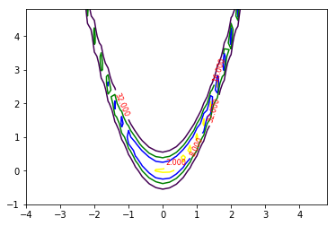

```python
%matplotlib inline
import matplotlib.pyplot as plt
def quest2(x,y):
    result=100*pow((y-pow(x,2)),2)+pow((1-x),2)
    return(result)
x = np.arange(-4,5,0.2)
y = np.arange(-1,5,0.2)

X,Y= np.meshgrid(x,y)

Z = quest2(X,Y)

plt.figure()
CS = plt.contour(X,Y,Z, [2],colors="yellow")
plt.clabel(CS,inline=True, fontsize=8,colors="red")
CS = plt.contour(X,Y,Z, [8],colors="blue")
plt.clabel(CS,inline=True, fontsize=8,colors="red")
CS = plt.contour(X,Y,Z, [16],colors="green")
plt.clabel(CS,inline=True, fontsize=8,colors="red")
CS = plt.contour(X,Y,Z, [32])
plt.clabel(CS,inline=True, fontsize=8,colors="red")
plt.show()
```

Question 3

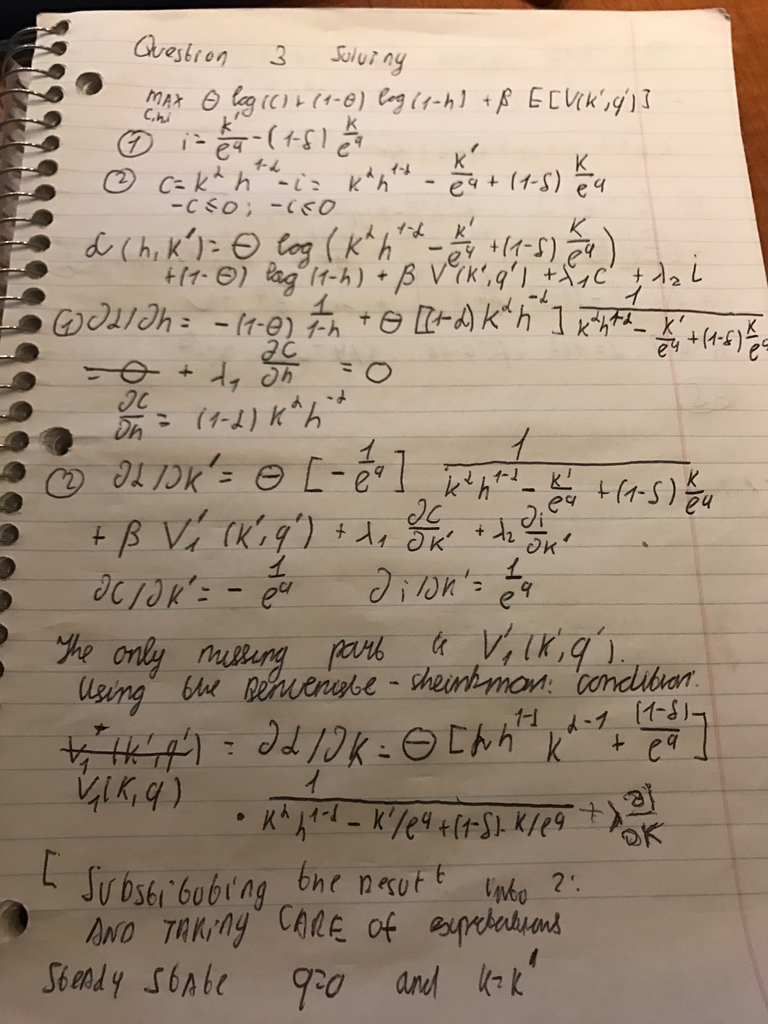

```python
from IPython.display import Image
from IPython.core.display import HTML
Image(filename ="photo1.jpg", width=500, height=500)
```

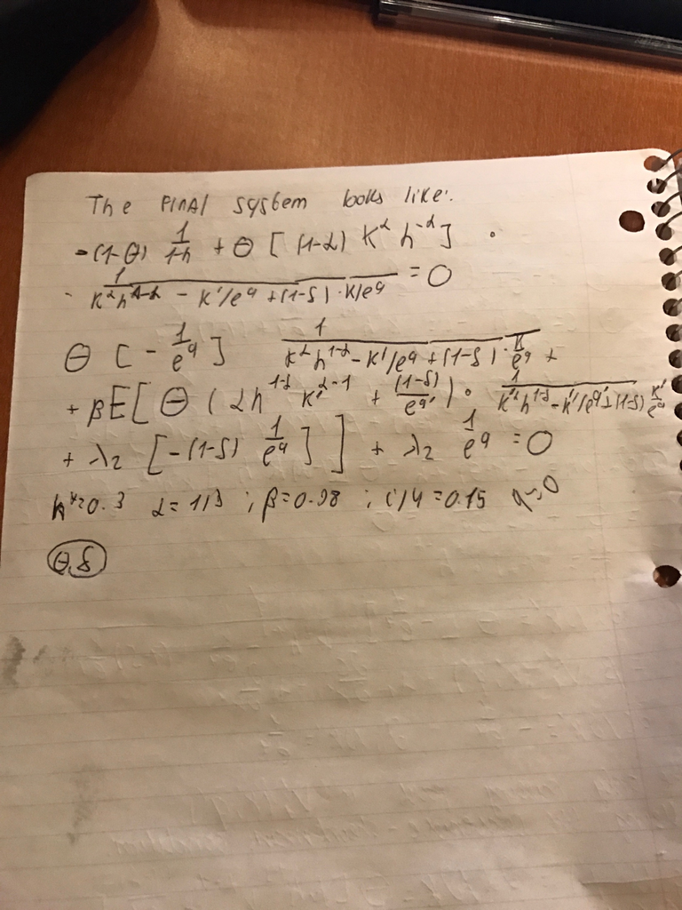

```python
Image(filename = "photo2.jpg", width=500, height=500)
```

```python
def devil_function(h,k,alpha,delta):
    result=1/(pow(k,alpha)*pow(h,1-alpha)-k+(1-delta)*k)
    return(result)
def quest3_1(array):
    #length of array is 3 or 4
    h=0.3
    k=array[0]
    phita=array[1]
    delta=array[2]
    alpha=1/3
    beta=0.98
    result=-(1-phita)*1/(1-h)+phita*((1-alpha)*pow(k,alpha)*pow(h,-alpha))*devil_function(h,k,alpha,delta)
    return(result)
def quest3_2(array):
    #length of array is 3
    h=0.3
    k=array[0]
    phita=array[1]
    delta=array[2]
    alpha=1/3
    beta=0.98
    lamda=0
    result=-phita*devil_function(h,k,alpha,delta)+beta* \
    (phita*(alpha*pow(h,1-alpha)*pow(k,alpha-1)+ \
    (1-delta))*devil_function(h,k,alpha,delta)-(1-delta)*lamda)+lamda
    return(result)
def quest3_3(array):
    #length of array is 3 or 4
    h=0.3
    k=array[0]
    phita=array[1]
    delta=array[2]
    alpha=1/3
    beta=0.98
    i=k-(1-delta)*k
    y=pow(k,alpha)*pow(h,1-alpha)
    result=i/y-0.15
    return(result)
def quest3_4(array):
    k=array[0]
    delta=array[2]
    #length of array is 4
    return(k-(1-delta)*k)
def quest3_5(array):
    #length of array is 4
    h=0.3
    k=array[0]
    phita=array[1]
    delta=array[2]
    alpha=1/3
    beta=0.98
    lamda=array[3]
    result=-phita*devil_function(h,k,alpha,delta)+beta* \
    (phita*(alpha*pow(h,1-alpha)*pow(k,alpha-1)+ \
    (1-delta))*devil_function(h,k,alpha,delta)-(1-delta)*lamda)+lamda
    return(result)

from scipy.optimize import fsolve
from scipy.optimize import root
import math

def unconstrained_problem(array):
    return (quest3_1(array), quest3_2(array),quest3_3(array))
def constrained_problem(array):
    return (quest3_5(array),quest3_1(array),quest3_3(array) ,quest3_4(array))

#print(fsolve(unconstrained_problem, (1, 1,1)))
#print(root(unconstrained_problem, (30, 30,30),method='broyden1'))
#print(quest3_4(fsolve(unconstrained_problem, (1, 1,1))))
#print(fsolve(constrained_problem, (1, 1,1,1)))
#print(quest3_4(fsolve(constrained_problem, (1, 1,1,1))))
```

```python
sol_unconst=root(unconstrained_problem, (4, 4,4),method='broyden1')
print(sol_unconst)
print(quest3_4(sol_unconst.x))
#sol_const=root(constrained_problem, (1, 1,1,1),method='broyden1')
#print(sol_const)
#print(quest3_4(fsolve(constrained_problem, (1, 1,1,1))))
```

```
     fun: array([  2.03203026e-06,   4.82886358e-06,   2.09615398e-06])
 message: 'A solution was found at the specified tolerance.'
     nit: 315
  status: 1
 success: True
       x: array([ 8.07105022,  0.35334867,  0.01670673])
0.134840860204
```

Checking the performance with a constraint

```python
sol_const=root(constrained_problem, (1, 1,1,1),method='lm',options={"maxiter": 20000})
print(sol_const)
print(quest3_4(sol_const.x))
```

```
   cov_x: None
    fjac: array([[  4.48317762e+06,  -1.37026697e+03,  -2.29061390e+01,
          3.40120227e+01],
       [ -1.37026697e+03,  -4.26230421e+00,  -3.74655638e-03,
         -1.70097847e-03],
       [ -2.29061390e+01,  -3.74656237e-03,  -3.14129475e-03,
         -1.42347645e-03],
       [  3.40120227e+01,  -1.70098329e-03,  -1.42351828e-03,
          7.70658884e-05]])
     fun: array([  4.88357520e-05,  -8.04752598e-09,  -1.29836962e-04,
         3.60145166e-03])
    ipvt: array([1, 2, 4, 3], dtype=int32)
 message: 'Number of calls to function has reached maxfev = 20000.'
    nfev: 20004
     qtf: array([ -4.88741546e-05,   9.87870774e-10,   1.29648568e-08,
        -3.60414933e-03])
  status: 5
 success: False
       x: array([  1.54185922e-04,   3.53383628e-01,   2.33578502e+01,
        -2.11418535e+01])
0.00360145165947
```

Question 4

a) $w(z)=\mu z+(1-\mu)b+\mu *k *\theta (z)$  
$0=-k+\beta E_z[q(\theta) J(z^{\prime})]$  
$E_z[J(z^{\prime})]=\frac{k}{q(\theta)\beta}$  
$J(z)=z-w(z)+\frac{(1-\delta) k}{q(\theta)}$  
Movin the last equation one period ahead and taking the expectations:  
$E[J(z^{\prime})]=E[z^{\prime}-w(z^{\prime})]+\frac{(1-\delta) k}{q(\theta)}$

$\frac{k}{q(\theta)\beta}=E[z^{\prime}-w(z^{\prime})]+\frac{(1-\delta) k}{q(\theta)}$

b) I used package Rtauchen in R to calculate the transition matrix. I import it from a csv file to python To do the calculation I am using the system of equations which on page 3 of lecture 3 slides. I also use the expression for m to get: $p=A\theta^{\alpha}$, $q=A\theta^{\alpha-1}$

```python
from scipy.optimize import root,fsolve,newton_krylov,anderson
import math
import csv
import numpy
reader = csv.reader(open("tauchen.csv", "r"), delimiter=",")
x = list(reader)
tauchen_matr = numpy.array(x).astype("float")
def Tauchen(n,m, sigma, autocorr):
    sigma_2 = sigma*(math.sqrt(1-autocorr**2))
    z_upper = m*sigma
    z_lower = -m*sigma
    z = []
    for i in range(1,11):
        z_i = z_lower + (z_upper - z_lower)*(i - 1)/(n-1)
        z.append(z_i)
    return(z)
n=10
sigma=0.002
autocorr=0.98
m=2
A=1
alpha=0.5
k=0.19
mu=0.5
b=0.4
beta=0.99
delta=0.02

tauchen=Tauchen(n,m, sigma, autocorr)
tauchen=numpy.array(tauchen)
def left_hand_side_function(array_of_z,array_of_fi):
    q=A*numpy.power(array_of_fi,alpha-1)
    print(q)
    return(k/(beta*q))
def right_hand_side_function(array_of_z,array_of_fi):
    q=A*numpy.power(array_of_fi,alpha-1)
    result=(1-mu)*(array_of_z-b)-mu*k*array_of_fi+(1-delta)*k/q
    return(result)
def equation_sys(array_of_fi):
    rhs=numpy.dot(tauchen_matr,right_hand_side_function(tauchen,array_of_fi))
    lhs=left_hand_side_function(tauchen,array_of_fi)
    return(rhs-lhs)
def rewriting_to_optimize(array_of_fi):
    result=0
    for i in equation_sys(array_of_fi):
        result+=i**2
    return(result)
```

```python
%%capture
#x0=(100,100,100,100,100,100,100,100,100,100)
#x1=(0.1,0.1,0.1,0.1,0.1,0.1,0.1,0.1,0.1,0.1)
#x2=(0.60144509,  0.59994397,  0.59840597,  0.5968676 ,  0.59532898,
#        0.59379026,  0.59225162,  0.5907132 ,  0.58917513,  0.58767388)
#x3=(0.001,0.001,0.001,0.001,0.001,0.001,0.001,0.001,0.001,0.001)
#x4=(0.0001,0.1,0.1,0.1,0.1,0.1,0.1,0.1,0.1,0.0001)
z5=numpy.random.uniform(low=0,high=1,size=10)
sol_unconst=root(equation_sys, z5,method="lm",options={"maxiter": 10000})
#sol_unconst=newton_krylov(equation_sys, x1)
#sol_unconst=anderson(equation_sys, x1)
```

```python
print("precision")
print(sol_unconst.fun)
print("estimated tightness")
print(sol_unconst.x)
```

```
precision
[-0.19088571 -0.22765609 -0.21725706 -0.21379571 -0.2026611  -0.20072436
 -0.20508319 -0.23634978 -0.24903524 -0.20316624]
estimated tightness
[  7.40344847e-14   1.75658478e-01   1.40984258e-01   9.98503026e-02
   3.37500652e-02   2.51006605e-02   6.47137634e-02   3.13608601e-01
   4.43484567e-01   9.72640473e-02]
```

Can not solve the system of equations. The root solving algorithm does not converge. My attempt at solving using polytope:

```python
%%capture
import scipy
list_of_different_results=[]
#for i in range(1,100):
z5=numpy.random.uniform(low=0.000000001,high=1,size=10)
result=scipy.optimize.minimize(rewriting_to_optimize, z5, method='Nelder-Mead',options={'maxiter':5000})
print(result)
#list_of_different_results.append(result)
#for i in list_of_different_results:
#    print(i.fun)
```

```python
print("precision")
print(result.fun)
print("estimated tightness")
print(result.x)
```

```
precision
0.511069976514
estimated tightness
[  2.68994290e-13   6.71486537e-02   1.30184551e-02   4.37744699e-01
   3.36820721e-02   7.39519235e-02   1.86472494e-01   4.67947098e-01
   9.99309043e-01   4.55233255e-03]
```

No luck here, too. For later parts I will be using the approximate values obtained before.

```python
import numpy
from statsmodels.tsa.filters.hp_filter import hpfilter
import pandas
#downloading series
unemp=pandas.DataFrame.from_csv("UNEMPLOY.csv")
vacancies=pandas.DataFrame.from_csv("JTSJOL.csv")
wages=pandas.DataFrame.from_csv("COMPRNFB.csv")
unrate=pandas.DataFrame.from_csv("UNRATE.csv")
#hpfilter and making sure that the series start on the same date
hpfil_unemp=hpfilter(unemp["UNEMPLOY"], lamb=1600)[1]
hpfil_unemp=hpfil_unemp[(len(hpfil_unemp)-1-201):(len(hpfil_unemp)-1)]
hpfil_unrate=hpfilter(unrate["UNRATE"], lamb=1600)[1]
hpfil_unrate=hpfil_unrate[(len(hpfil_unrate)-1-201):(len(hpfil_unrate)-1)]
hpfil_vacancies=hpfilter(vacancies["JTSJOL"], lamb=1600)[1]
hpfil_wages=hpfilter(wages["COMPRNFB"], lamb=1600)[1]
#calculating market tightness
phi=hpfil_vacancies/hpfil_unemp
#converting from quarterly from monthly
quarterizer=range(3,200,3)
quarterizer=list(quarterizer)
hpfil_unemp=hpfil_unemp[quarterizer]
hpfil_unrate=hpfil_unrate[quarterizer]
hpfil_vacancies=hpfil_vacancies[quarterizer]
phi=phi[quarterizer]
#taking logs
hpfil_unemp=numpy.log(hpfil_unemp)
hpfil_vacancies=numpy.log(hpfil_vacancies)
hpfil_unrate=numpy.log(hpfil_unrate)
phi=numpy.log(phi)
hpfil_wages=numpy.log(hpfil_wages)
#printing output
print("std of unemployment rate")
print(numpy.std(hpfil_unrate))
print("std of unemployment level")
print(numpy.std(hpfil_unemp))
print("std of vacancies")
print(numpy.std(hpfil_vacancies))
print("std of market tightness")
print(numpy.std(phi))
print("std of wage")
print(numpy.std(hpfil_wages))
```

```
std of unemployment rate
0.24922892219651033
std of unemployment level
0.25575710763551374
std of vacancies
0.21706890532676604
std of market tightness
0.4364578445743106
std of wage
0.2923752843079362
```

```python
#just checking for inital values
print(hpfil_unrate.head(n=5))
print(hpfil_unemp.head(n=5))
```

```
DATE
2001-03-01    1.496258
2001-06-01    1.551343
2001-09-01    1.608754
2001-12-01    1.661804
2002-03-01    1.705722
Name: UNRATE, dtype: float64
DATE
2001-03-01    8.767787
2001-06-01    8.824701
2001-09-01    8.883801
2001-12-01    8.938488
2002-03-01    8.983996
Name: UNEMPLOY, dtype: float64
```

Going to simulation. THe Shimmer puzzle arises because the simulated statndard deviations are way smaller than the empirical values.

```python
def simulator(phi_in_state):
    niter=10500
    init_state=0
    state=init_state
#taking initial employment from the actual series
    unemp_init=8.767787
#states chosen by markov process
    states=[0,1,2,3,4,5,6,7,8,9]
#vector of nodes
    z_in_state=tauchen
    iters=1
    phis=[]
    ws=[]
    vacancies=[]
    unemployment_level=[]
    while iters<=niter:
#get phi depending on state
        phi=phi_in_state[state]
#calculating the wage given the formula in slides
        w=1-mu*z_in_state[state]+(1-mu)*b+mu*k*phi
#appending wage and tightness to the series and unemployment
        phis.append(phi)
        ws.append(w)
        unemployment_level.append(unemp_init)
#Calculating and uppending vacancies using a simple relationship
        vacancy=phi*unemp_init
        vacancies.append(vacancy)
#calculating future state
        state=numpy.random.choice(a=states,p=tauchen_matr[state,])
#calculating current probability of job finding and future unemployment
        p=A*(phi**alpha)
        unemp_init=unemp_init-p*unemp_init+delta*(1-unemp_init)
        iters+=1
#deleting first 500 observations
    phis=phis[500:]
    ws=ws[500:]
    vacancies=vacancies[500:]
    unemployment_level=unemployment_level[500:]
#output
    print("std of unemployment level")
    print(numpy.std(unemployment_level))
    print("std of vacancies")
    print(numpy.std(vacancies))
    print("std of market tightness")
    print(numpy.std(phis))
    print("std of wage")
    print(numpy.std(ws))
#calling the function
phi_in_state=list(sol_unconst.x)
simulator(phi_in_state)
```

```
std of unemployment level
0.0283385931487
std of vacancies
0.00488312778498
std of market tightness
0.12051148414
std of wage
0.0110698476547
```

```python
%%capture
b=0.9
z5=numpy.random.uniform(low=0,high=1,size=10)
sol_unconst2=root(equation_sys, z5,method="lm",options={"maxiter": 10000})
```

```python
print("precision")
print(sol_unconst2.fun)
print("estimated tightness")
print(sol_unconst2.x)
```

```
precision
[-0.44980254 -0.44756436 -0.45858295 -0.51596918 -0.46571913 -0.47363797
 -0.49728747 -0.51796733 -0.43767398 -0.49613297]
estimated tightness
[  5.26799504e-13   4.15607831e-03   8.62512602e-02   5.55823396e-01
   1.78778901e-01   2.32829418e-01   4.48443249e-01   6.04761979e-01
   3.04296982e-02   3.76741806e-01]
```

While the puzzle is not solved, the simulated standard deviation are larger.

```python
phi_in_state=list(sol_unconst2.x)
print("Outcome of new simulations:")
simulator(phi_in_state)
```

```
Outcome of new simulations:
std of unemployment level
0.0528781316201
std of vacancies
0.00809504481901
std of market tightness
0.206635716762
std of wage
0.0192716811505
```

The code below can be used to mess with parameters.

```python
%%capture
#n=10
#sigma=0.002
#autocorr=0.98
#m=2
A=1
alpha=0.5
k=0.19
mu=0.5
b=0.4
beta=0.99
delta=0.02
#changing delta
delta=0.1
z5=numpy.random.uniform(low=0,high=1,size=10)
sol_unconst3=root(equation_sys, z5,method="lm",options={"maxiter": 10000})
phi_in_state=list(sol_unconst3.x)
```

```python
simulator(phi_in_state)
#Delta has big impact on unemployment
```

```
std of unemployment level
0.149783477117
std of vacancies
0.0350877345919
std of market tightness
0.159351881269
std of wage
0.0150854178611
```